# rgl Overview

Duncan Murdoch

April 21, 2021

```
## undoing setup
```

## Introduction

The `rgl` package is used to produce interactive 3-D plots. It contains high-level graphics commands modelled loosely after classic R graphics, but working in three dimensions. It also contains low level structure inspired by (but incompatible with) the `grid` package.

This document gives an overview. See the help pages for details.

For installation instructions, see the `README` file in the top level directory of the source tarball rgl_0.106.8.tar.gz (or a later version).

### About this document

This document was written in R Markdown, using the `knitr` package for production. It corresponds to `rgl` version 0.106.8.

Most of the highlighted function names are HTML links. The internal links should work in any browser; the links to help topics should work if you view the vignette from within the R help system.

The document includes WebGL figures. To view these, you must have Javascript and WebGL enabled in your browser. Some older browsers may not support this – see https://get.webgl.org for tests and links to a discussion.

## Basics and High Level Functions

The [`plot3d`](https://dmurdoch.github.io/rgl/dev/reference/plot3d.html) function plots points within an RGL window. It is similar to the classic [`plot`](https://rdrr.io/r/graphics/plot.default.html) function, but works in 3 dimensions.

For example

```r
with(iris, plot3d(Sepal.Length, Sepal.Width, Petal.Length,
                  type="s", col=as.numeric(Species)))
```

[interactive chart not shown]

can be used to plot three columns of the `iris` data. Allowed plot types include `"p", "l", "h", "s"`, meaning points, lines, segments from z=0, and spheres. There’s a lot of flexibility in specifying the coordinates; the [`xyz.coords`](https://rdrr.io/r/grDevices/xyz.coords.html) function from the `grDevices` package is used for this.

You can use your mouse to manipulate the plot. The default is that if you click and hold with the left mouse button, you can rotate the plot by dragging it. The right mouse button is used to resize it, and the middle button changes the perspective in the point of view.

If you call `plot3d` again, it will overwrite the current plot. To open a new graphics window, use `open3d`.

The other high level function is [`persp3d`](https://dmurdoch.github.io/rgl/dev/reference/persp3d.html) to draw surfaces. It is similar to the classic [`persp`](https://rdrr.io/r/graphics/persp.html) function, but with greater flexibility. First, any of `x`, `y` or `z` can be specified using matrices, not just `z`. This allows parametric surfaces to be plotted. An even simpler specification is possible: `x` may be a function, in which case `persp3d` will work out the grid itself. See [?persp3d.function](https://dmurdoch.github.io/rgl/dev/reference/persp3d.function.html) for details. For example, the `MASS` package estimates Gamma parameters using maximum likelihood in a [?MASS::fitdistr](https://rdrr.io/pkg/MASS/man/fitdistr.html) example. Here we show the log likelihood surface.

```r
library(MASS)
# from the fitdistr example
set.seed(123)
x <- rgamma(100, shape = 5, rate = 0.1)
fit <- fitdistr(x, dgamma, list(shape = 1, rate = 0.1), lower = 0.001)
loglik <- function(shape, rate) sum(dgamma(x, shape=shape, rate=rate,
                                           log=TRUE))
loglik <- Vectorize(loglik)
xlim <- fit$estimate[1]+4*fit$sd[1]*c(-1,1)
ylim <- fit$estimate[2]+4*fit$sd[2]*c(-1,1)

mfrow3d(1, 2, sharedMouse = TRUE)
persp3d(loglik,
        xlim = xlim, ylim = ylim,
        n = 30)
zlim <- fit$loglik + c(-qchisq(0.99, 2)/2, 0)
next3d()
persp3d(loglik,
        xlim = xlim, ylim = ylim, zlim = zlim,
        n = 30)
```

[interactive chart not shown]

On the left, the whole surface over a range of the parameters; on the right, only the parts of the surface with log likelihood values near the maximum.

Note: this example used the `knitr` hook functions (see `setupKnitr`) to insert the scene into this vignette; the previous example used the `rglwidget` function. We generally recommend the newer `rglwidget` approach.

Note that both `plot3d` and `persp3d` are generic functions, with the following methods defined:

```r
methods(plot3d)
```

```
##  [1] plot3d.ashape3d*      plot3d.default*       plot3d.deldir*
##  [4] plot3d.formula*       plot3d.function*      plot3d.lm*
##  [7] plot3d.mesh3d*        plot3d.rglWebGL*      plot3d.rglbackground*
## [10] plot3d.rglbboxdeco*   plot3d.rglobject*     plot3d.rglscene*
## [13] plot3d.rglsubscene*   plot3d.tri*           plot3d.triSht*
## see '?methods' for accessing help and source code
```

```r
methods(persp3d)
```

```
## [1] persp3d.ashape3d* persp3d.default*  persp3d.deldir*   persp3d.formula*
## [5] persp3d.function* persp3d.tri*      persp3d.triSht*
## see '?methods' for accessing help and source code
```

## Adding Graphical Elements

### Primitive shapes

Just as we have [`points`](https://rdrr.io/r/graphics/points.html) and [`lines`](https://rdrr.io/r/graphics/lines.html) in classic graphics, there are a number of low level functions in `rgl` to add graphical elements to the currently active plot. The “primitive” shapes are those that are native to OpenGL:

| Function | Description |
| --- | --- |
| [`points3d`](https://dmurdoch.github.io/rgl/dev/reference/3dobjects.html): | adds points |
| [`lines3d`](https://dmurdoch.github.io/rgl/dev/reference/3dobjects.html): | adds lines |
| [`segments3d`](https://dmurdoch.github.io/rgl/dev/reference/3dobjects.html): | adds line segments |
| [`triangles3d`](https://dmurdoch.github.io/rgl/dev/reference/3dobjects.html): | adds triangles |
| [`quads3d`](https://dmurdoch.github.io/rgl/dev/reference/3dobjects.html): | adds quadrilaterals |

Each of the above functions takes arguments `x`, `y` and `z`, again using [`xyz.coords`](https://rdrr.io/r/grDevices/xyz.coords.html) for flexibility. They group successive entries as necessary. For example, the `triangles3d` function takes each successive triple of points as the vertices of a triangle.

You can use these functions to annotate the current graph, or to construct a figure from scratch.

### Constructed shapes

`rgl` also has a number of objects which it constructs from the primitives.

| Function | Description |
| --- | --- |
| [`text3d`](https://dmurdoch.github.io/rgl/dev/reference/texts.html), [`texts3d`](https://dmurdoch.github.io/rgl/dev/reference/texts.html): | adds text |
| [`abclines3d`](https://dmurdoch.github.io/rgl/dev/reference/abclines.html): | adds straight lines to plot (like `abline`) |
| [`arc3d`](https://dmurdoch.github.io/rgl/dev/reference/arc3d.html): | adds spherical arcs or spirals to plot |
| [`planes3d`](https://dmurdoch.github.io/rgl/dev/reference/planes.html): | adds planes to plot |
| [`clipplanes3d`](https://dmurdoch.github.io/rgl/dev/reference/planes.html): | add clipping planes to plot |
| [`sprites3d`](https://dmurdoch.github.io/rgl/dev/reference/sprites.html), [`particles3d`](https://dmurdoch.github.io/rgl/dev/reference/sprites.html): | add sprites (fixed shapes or images) to plot |
| [`spheres3d`](https://dmurdoch.github.io/rgl/dev/reference/spheres.html): | adds spheres |
| [`surface3d`](https://dmurdoch.github.io/rgl/dev/reference/surface3d.html), [`terrain3d`](https://dmurdoch.github.io/rgl/dev/reference/surface3d.html): | a surface (as used in `persp3d`) |
| [`drape3d`](https://dmurdoch.github.io/rgl/dev/reference/drape3d.html): | drapes lines on a surface or object(s) |
| [`shadow3d`](https://dmurdoch.github.io/rgl/dev/reference/shadow3d.html): | projects mesh onto a surface |
| [`arrow3d`](https://dmurdoch.github.io/rgl/dev/reference/arrow3d.html): | add an arrow to a scene |
| [`pch3d`](https://dmurdoch.github.io/rgl/dev/reference/pch3d.html): | draw base-style plotting symbols |
| [`plotmath3d`](https://dmurdoch.github.io/rgl/dev/reference/plotmath3d.html): | used by `text3d` for math text |

### Axes and other “decorations”

The following low-level functions control the look of the graph:

| Function | Description |
| --- | --- |
| [`axes3d`](https://dmurdoch.github.io/rgl/dev/reference/axes3d.html), [`axis3d`](https://dmurdoch.github.io/rgl/dev/reference/axes3d.html): | add axes to plot |
| [`box3d`](https://dmurdoch.github.io/rgl/dev/reference/axes3d.html), [`bbox3d`](https://dmurdoch.github.io/rgl/dev/reference/axes3d.html): | add box around plot |
| [`title3d`](https://dmurdoch.github.io/rgl/dev/reference/axes3d.html): | add title to plot |
| [`mtext3d`](https://dmurdoch.github.io/rgl/dev/reference/axes3d.html): | add marginal text to plot |
| [`decorate3d`](https://dmurdoch.github.io/rgl/dev/reference/decorate3d.html): | add multiple “decorations” (scales, etc.) to plot |
| [`aspect3d`](https://dmurdoch.github.io/rgl/dev/reference/aspect3d.html): | set the aspect ratios for the plot |
| [`bg3d`](https://dmurdoch.github.io/rgl/dev/reference/bg.html), [`bgplot3d`](https://dmurdoch.github.io/rgl/dev/reference/bg.html): | set the background of the scene |
| [`show2d`](https://dmurdoch.github.io/rgl/dev/reference/show2d.html): | show a 2D plot or image in a 3D scene |
| [`legend3d`](https://dmurdoch.github.io/rgl/dev/reference/bgplot3d.html): | set a legend for the scene |
| [`grid3d`](https://dmurdoch.github.io/rgl/dev/reference/grid3d.html): | add a reference grid to a graph |
| [`thigmophobe3d`](https://dmurdoch.github.io/rgl/dev/reference/thigmophobe3d.html): | choose label positions to avoid overlap |

For example, to plot three random triangles, one could use

```r
triangles3d(cbind(x=rnorm(9), y=rnorm(9), z=rnorm(9)), col = "green")
decorate3d()
bg3d("lightgray")
```

[interactive chart not shown]

```r
aspect3d(1,1,1)
```

Besides the `*3d` functions mentioned above, there are even lower-level functions [`rgl.primitive`](https://dmurdoch.github.io/rgl/dev/reference/primitive.html), [`rgl.points`](https://dmurdoch.github.io/rgl/dev/reference/primitive.html), [`rgl.linestrips`](https://dmurdoch.github.io/rgl/dev/reference/primitive.html), [`rgl.lines`](https://dmurdoch.github.io/rgl/dev/reference/primitive.html), [`rgl.triangles`](https://dmurdoch.github.io/rgl/dev/reference/primitive.html), [`rgl.quads`](https://dmurdoch.github.io/rgl/dev/reference/primitive.html), [`rgl.texts`](https://dmurdoch.github.io/rgl/dev/reference/primitive.html), [`rgl.abclines`](https://dmurdoch.github.io/rgl/dev/reference/primitive.html), [`rgl.planes`](https://dmurdoch.github.io/rgl/dev/reference/primitive.html), [`rgl.bg`](https://dmurdoch.github.io/rgl/dev/reference/primitive.html), [`rgl.clipplanes`](https://dmurdoch.github.io/rgl/dev/reference/primitive.html), [`rgl.bbox`](https://dmurdoch.github.io/rgl/dev/reference/primitive.html), [`rgl.spheres`](https://dmurdoch.github.io/rgl/dev/reference/primitive.html), [`rgl.sprites`](https://dmurdoch.github.io/rgl/dev/reference/primitive.html), [`rgl.surface`](https://dmurdoch.github.io/rgl/dev/reference/primitive.html).  
You should avoid using these functions, which do not work well with the higher level `*3d` functions. See the [?r3d](https://dmurdoch.github.io/rgl/dev/reference/r3d.html) help topic for details.

## Controlling the Look of the Scene

### Lighting

In most scenes, objects are “lit”, meaning that their appearance depends on their position and orientation relative to lights in the scene. The lights themselves don’t normally show up, but their effect on the objects does.

Use the [`light3d`](https://dmurdoch.github.io/rgl/dev/reference/light.html) function to specify the position and characteristics of a light. Lights may be infinitely distant, or may be embedded within the scene. Their characteristics include `ambient`, `diffuse`, and `specular` components, all defaulting to white. The `ambient` component appears the same from any direction. The `diffuse` component depends on the angle between the surface and the light, while the `specular` component also takes the viewer’s position into account.

The [`rgl.light`](https://dmurdoch.github.io/rgl/dev/reference/light.html) function is a lower-level function with different defaults; users should normally use `light3d`.

### Materials

The mental model used in `rgl` is that the objects being shown in scenes are physical objects in space, with material properties that affect how light reflects from them (or is emitted by them). These are mainly controlled by the [`material3d`](https://dmurdoch.github.io/rgl/dev/reference/material.html) function, or by arguments to other functions that are passed to it.

The material properties that can be set by calls to `material3d` are described in detail in the [?material3d](https://dmurdoch.github.io/rgl/dev/reference/material.html) help page. Here we give an overview.

| Property | Default | Meaning |
| --- | --- | --- |
| color | white | vector of surface colors to apply to successive vertices for diffuse light |
| alpha | 1 | transparency: 0 is invisible, 1 is opaque |
| lit | TRUE | whether lighting calculations should be done |
| ambient | black | color in ambient light |
| specular | white | color in specular light |
| emission | black | color emitted by the surface |
| shininess | 50 | controls the specular lighting: high values look shiny |
| smooth | TRUE | whether shading should be interpolated between vertices |
| texture | NULL | optional path to a “texture” bitmap to be displayed on the surface |
| front, back | fill | should polygons be filled, or outlined? |
| size | 3 | size of points in pixels |
| lwd | 1 | width of lines in pixels |

Other properties include “texmipmap”, “texmagfilter”, “texminfilter”, “texenvmap”, “fog”, “point_antialias”, “line_antialias”, “depth_mask”, “depth_test” and “polygon_offset”; see [the help page](https://dmurdoch.github.io/rgl/dev/reference/material.html) for details.

There is also an [`rgl.material`](https://dmurdoch.github.io/rgl/dev/reference/material.html) function that works at a lower level; users should normally avoid it.

### Textures

As described in the previous section, one of the material properties is `texture`, the name of a bitmap file (in `.png` format) containing an image to be displayed on the surface. This section gives more details about textures.

In `OpenGL`, each vertex in a polygon may be associated with a particular location in the bitmap. The interior of the polygon interpolates within the bitmap. There are two conventions in `rgl` functions for specifying these coordinates.

Functions which specify primitives (`triangles3d`, etc.) accept an optional matrix argument `texcoords` which gives `s` (horizontal) and `t` (vertical) locations within the bitmap in columns with one row per vertex. The coordinates are `(0,0)` for the lower left, and `(1,1)` for the upper right. If values outside this range are given, the image repeats, i.e. `(1.1, 1.1)` would specify the same point in the image as `(0.1, 0.1)`.

Other functions such as `surface3d` that take matrices for each vertex coordinate accept texture coordinates as matrices as well, in arguments `texture_s` and `texture_t`.

For example, the following code displays four copies of a 2D plot on a quad, because the texture coordinates run from 0 to 2 in both `s` and `t`:

```r
filename <- tempfile(fileext = ".png")
png(filename = filename)
plot(rnorm(1000), rnorm(1000))
dev.off()
```

```r
open3d()
```

```
## null
##   29
```

```r
xyz <- cbind(c(0,1,1,0), 0, c(0,0,1,1))
quads3d(xyz, texture = filename, texcoords = xyz[,c(1, 3)]*2, col = "white", specular = "black")
```

[interactive chart not shown]

Some other notes:

- The color in the figure above was specified to be white. By default, the colors in the bitmap will modify the colour of the quad. If `col` is black (a common default), you won’t see anything.
- On the other hand, you usually don’t want specular reflections (which show up as glare). Setting `specular` to black prevents those.
- How the bitmap is handled is controlled by the material property `"textype"`. The default is `"rgb"`, which takes the red-green-blue colours from the bitmap and uses them to modify the corresponding colours in the polygon. Other possibilities for `"textype"` are described in [the material3d help page](https://dmurdoch.github.io/rgl/dev/reference/material.html).
- The other `"tex*"` material properties control how the interpolation within the image is done.
- Modern `OpenGL` supports 1- and 3-dimensional textures; these are not supported in `rgl`.

### Fonts

`rgl` uses the same ideas as base graphics for drawing text: there are font families named `"sans"`, `"serif"`, and `"mono"` for drawing text of those types. In `rgl`, the `"symbol"` family is not supported.

New font families can be defined using the low-level function [`rglFonts`](https://dmurdoch.github.io/rgl/dev/reference/rgl.texts.html), or more simply using the higher level function [`rglExtrafonts`](https://dmurdoch.github.io/rgl/dev/reference/rglExtrafonts.html). The latter function requires the `extrafont` package to be installed.

### par3d: Miscellaneous graphical parameters

The [`par3d`](https://dmurdoch.github.io/rgl/dev/reference/par3d.html) function, modelled after the classic graphics [`par`](https://rdrr.io/r/graphics/par.html) function, sets or reads a variety of different `rgl` internal parameters. Some parameters are completely read-only; others are fixed at the time the window is opened, and others may be changed at any time.

| Name | Changeable? | Description |
| --- | --- | --- |
| antialias | fixed | Amount of hardware antialiasing |
| cex |  | Default size for text |
| family |  | Device-independent font family name; see [?text3d](https://dmurdoch.github.io/rgl/dev/reference/texts.html) |
| font |  | Integer font number |
| useFreeType |  | Should FreeType fonts be used if available? |
| fontname | read-only | System-dependent font name set by `rglFonts` |
| FOV |  | Field of view, in degrees. Zero means isometric perspective |
| ignoreExtent |  | Should `rgl` ignore the size of new objects when computing the bounding box? |
| skipRedraw |  | Should `rgl` suppress updates to the display? |
| maxClipPlanes | read-only | How many clip planes can be defined? |
| modelMatrix | read-only | The OpenGL ModelView matrix; partly set by [`view3d`](https://dmurdoch.github.io/rgl/dev/reference/viewpoint.html) or the obsolete [`rgl.viewpoint`](https://dmurdoch.github.io/rgl/dev/reference/viewpo… |
| projMatrix | read-only | The OpenGL Projection matrix |
| bbox | read-only | Current bounding-box of the scene |
| viewport |  | Dimensions in pixels of the scene within the window |
| windowRect |  | Dimensions in pixels of the window on the whole screen |
| listeners |  | Which subscenes respond to mouse actions in the current one |
| mouseMode |  | What the mouse buttons do. See `“mouseMode”` |
| observer | read-only | The position of the observer; set by [`observer3d`](https://dmurdoch.github.io/rgl/dev/reference/observer3d.html) |
| scale |  | Rescaling for each coordinate; see `aspect3d` |
| zoom |  | Magnification of the scene |

### Default settings

The [`r3dDefaults`](https://dmurdoch.github.io/rgl/dev/reference/open3d.html) list and the [`getr3dDefaults`](https://dmurdoch.github.io/rgl/dev/reference/open3d.html) function control defaults in new windows opened by `open3d`.  
The function looks for the variable in the user’s global environment, and if not found there, finds the one in the `rgl` namespace. This allows the user to override the default settings for new windows.

Once found, the `r3dDefaults` list provides initial values for `par3d` parameters, as well as defaults for `material3d` and `bg3d` in components `"material"` and `"bg"` respectively.

## Meshes: Constructing Shapes

`rgl` includes a number of functions to construct and display various solid shapes. These generate objects of class `"shape3d"`, `"mesh3d"` or `"shapelist3d"`. The details of the classes are described below. We start with functions to generate them.

### Specific solids

These functions generate specific shapes. Optional arguments allow attributes such as colour or transformations to be specified.

| Function | Description |
| --- | --- |
| [`tetrahedron3d`](https://dmurdoch.github.io/rgl/dev/reference/cube3d.html), [`cube3d`](https://dmurdoch.github.io/rgl/dev/reference/cube3d.html), [`octahedron3d`](https://dmurdoch.github.io/rgl/dev/r… | Platonic solids |
| [`cuboctahedron3d`](https://dmurdoch.github.io/rgl/dev/reference/cube3d.html), [`oh3d`](https://dmurdoch.github.io/rgl/dev/reference/cube3d.html): | other solids |

```r
cols <- rainbow(7)
layout3d(matrix(1:16, 4,4), heights=c(1,3,1,3))
text3d(0,0,0,"tetrahedron3d"); next3d()
shade3d(tetrahedron3d(col=cols[1])); next3d()
text3d(0,0,0,"cube3d"); next3d()
shade3d(cube3d(col=cols[2])); next3d()
text3d(0,0,0,"octahedron3d"); next3d()
shade3d(octahedron3d(col=cols[3])); next3d()
text3d(0,0,0,"dodecahedron3d"); next3d()
shade3d(dodecahedron3d(col=cols[4])); next3d()
text3d(0,0,0,"icosahedron3d"); next3d()
shade3d(icosahedron3d(col=cols[5])); next3d()
text3d(0,0,0,"cuboctahedron3d"); next3d()
shade3d(cuboctahedron3d(col=cols[6])); next3d()
text3d(0,0,0,"oh3d"); next3d()
shade3d(oh3d(col=cols[7]))
```

[interactive chart not shown]

A very large collection of polyhedra is contained in the Rpolyhedra package.

### Generating new shapes

These functions generate new shapes:

| Function | Description |
| --- | --- |
| [`cylinder3d`](https://dmurdoch.github.io/rgl/dev/reference/cylinder3d.html): | generate a tube or cylinder |
| [`polygon3d`](https://dmurdoch.github.io/rgl/dev/reference/polygon3d.html): | generate a flat polygon by triangulation |
| [`extrude3d`](https://dmurdoch.github.io/rgl/dev/reference/extrude3d.html): | generate an “extrusion” of a polygon |
| [`turn3d`](https://dmurdoch.github.io/rgl/dev/reference/turn3d.html): | generate a solid of rotation |
| [`ellipse3d`](https://dmurdoch.github.io/rgl/dev/reference/ellipse3d.html): | generate an ellipsoid in various ways |
| [`mesh3d`](https://dmurdoch.github.io/rgl/dev/reference/mesh3d.html): | generate a shape from indexed vertices |
| [`shapelist3d`](https://dmurdoch.github.io/rgl/dev/reference/shapelist3d.html): | generate a shape by combining other shapes |
| `as.mesh3d`: | a generic function; see below |

A related function is [`triangulate`](https://dmurdoch.github.io/rgl/dev/reference/triangulate.html), which takes a two dimensional polygon and divides it up into triangles using the “ear-clipping” algorithm.

The generic function [`as.mesh3d`](https://dmurdoch.github.io/rgl/dev/reference/as.mesh3d.default.html) is provided to allow data structures produced by other code to be converted to mesh structures. Currently the following classes are supported:

| Class | Package | Description |
| --- | --- | --- |
| [`deldir`](https://rdrr.io/pkg/deldir/man/deldir.html) | `deldir` | Delaunay triangulations of irregular point clouds |
| [`triSht`](https://rdrr.io/pkg/interp/man/triSht.html) | `interp` | Also Delaunay triangulations |
| [`tri`](https://rdrr.io/pkg/tripack/man/tri.html) | `tripack` | Generalized Delaunay triangulations |
| [`ashape3d`](https://rdrr.io/pkg/alphashape3d/man/ashape3d.html) | `alphashape3d` | Alpha-shapes |
| `rglId` | `rgl` | `rgl` object identifiers |

The default [`as.mesh3d.default`](https://dmurdoch.github.io/rgl/dev/reference/as.mesh3d.default.html) method is a simple way to construct a mesh from a matrix of vertices; it can use [`mergeVertices`](https://dmurdoch.github.io/rgl/dev/reference/mergeVertices.html) (which can also be used on its own) to merge repeated vertices within the matrix, allowing `addNormals` to be used to give a smooth appearance.

Functions [`tmesh3d`](https://dmurdoch.github.io/rgl/dev/reference/mesh3d.html), [`qmesh3d`](https://dmurdoch.github.io/rgl/dev/reference/mesh3d.html) are now obsolete; use `mesh3d` instead.

### The underlying class structure for shapes

`"shape3d"` is the basic abstract type. Objects of this class can be displayed by [`shade3d`](https://dmurdoch.github.io/rgl/dev/reference/shade3d.html) (which shades faces), [`wire3d`](https://dmurdoch.github.io/rgl/dev/reference/shade3d.html) (which draws edges), or [`dot3d`](https://dmurdoch.github.io/rgl/dev/reference/shade3d.html) (which draws points at each vertex.)

`"mesh3d"` is a descendant type. Objects of this type contain the following fields:

| Field | Meaning |
| --- | --- |
| vb | A 4 by n matrix of vertices in homogeneous coordinates. Each column is a point. |
| ip | (optional) A vector of vertex indices for points. |
| is | (optional) A 2 by s matrix of vertex indices. Each column is a line segment. |
| it | (optional) A 3 by t matrix of vertex indices. Each column is a triangle. |
| ib | (optional) A 4 by q matrix of vertex indices. Each column is a quadrilateral. |
| material | (optional) A list of material properties. |
| normals | (optional) A matrix of the same shape as vb, containing normal vectors at each vertex. |
| texcoords | (optional) A 2 by n matrix of texture coordinates corresponding to each vertex. |
| values | (optional) A vector of length n holding values at each vertex |
| meshColor | (optional) A text value indicating how colors and texture coordinates should be interpreted. |

### Contouring shapes

These functions compute and plot contours of functions on surfaces, or clip objects along a contour of a function.

| Function | Description |
| --- | --- |
| [`contourLines3d`](https://dmurdoch.github.io/rgl/dev/reference/contourLines3d.html): | draw contour lines on surface |
| [`filledContour3d`](https://dmurdoch.github.io/rgl/dev/reference/contourLines3d.html): | fill between contours on surface |
| [`clipMesh3d`](https://dmurdoch.github.io/rgl/dev/reference/clipMesh3d.html): | clip mesh object using curved boundary |
| [`clipObj3d`](https://dmurdoch.github.io/rgl/dev/reference/clipMesh3d.html): | clip general object using curved boundary |

### Manipulating shapes

These functions manipulate and modify mesh objects:

| Function | Description |
| --- | --- |
| [`addNormals`](https://dmurdoch.github.io/rgl/dev/reference/addNormals.html): | add normal vectors to make a shape look smooth |
| [`subdivision3d`](https://dmurdoch.github.io/rgl/dev/reference/subdivision3d.html): | add extra vertices to make it look even smoother |
| [`merge`](https://dmurdoch.github.io/rgl/dev/reference/merge.mesh3d.html): | merge mesh objects |
| [`facing3d`](https://dmurdoch.github.io/rgl/dev/reference/facing3d.html): | subset of mesh facing “up” |

The individual steps in `subdivision3d` are also available: [`deform.mesh3d`](https://dmurdoch.github.io/rgl/dev/reference/subdivision3d.html), [`divide.mesh3d`](https://dmurdoch.github.io/rgl/dev/reference/subdivision3d.html), [`normalize.mesh3d`](https://dmurdoch.github.io/rgl/dev/reference/subdivision3d.html). These are mainly intended for internal use.

## Multi-figure Layouts

`rgl` has several functions to support displaying multiple different “subscenes” in the same window. The high level functions are

| Function | Description |
| --- | --- |
| [`mfrow3d`](https://dmurdoch.github.io/rgl/dev/reference/mfrow3d.html): | Multiple figures (like [par(“mfrow”)](https://rdrr.io/r/graphics/par.html) |
| [`layout3d`](https://dmurdoch.github.io/rgl/dev/reference/mfrow3d.html): | Multiple figures (like [`layout`](https://rdrr.io/r/graphics/layout.html)) |
| [`next3d`](https://dmurdoch.github.io/rgl/dev/reference/mfrow3d.html): | Move to the next figure (like [`plot.new`](https://rdrr.io/r/graphics/frame.html) or [`frame`](https://rdrr.io/r/graphics/frame.html)) |
| [`subsceneList`](https://dmurdoch.github.io/rgl/dev/reference/mfrow3d.html): | List all the subscenes in the current layout |
| [`clearSubsceneList`](https://dmurdoch.github.io/rgl/dev/reference/mfrow3d.html): | Clear the current list and revert to the previous one |

There are also lower level functions.

| Function | Description |
| --- | --- |
| [`newSubscene3d`](https://dmurdoch.github.io/rgl/dev/reference/subscene3d.html): | Create a new subscene, with fine control over what is inherited from the parent |
| [`currentSubscene3d`](https://dmurdoch.github.io/rgl/dev/reference/subscene3d.html): | Report on the active subscene |
| [`subsceneInfo`](https://dmurdoch.github.io/rgl/dev/reference/subsceneInfo.html): | Get information on current subscene |
| [`useSubscene3d`](https://dmurdoch.github.io/rgl/dev/reference/subscene3d.html): | Make a different subscene active |
| [`addToSubscene3d`](https://dmurdoch.github.io/rgl/dev/reference/subscene3d.html), [`delFromSubscene3d`](https://dmurdoch.github.io/rgl/dev/reference/subscene3d.html): | Add objects to a subscene, or delete them |
| [`gc3d`](https://dmurdoch.github.io/rgl/dev/reference/subscene3d.html): | Do “garbage collection”: delete objects that are not displayed in any subscene |

## Documents with `rgl` Scenes

The `rgl` package can produce output that can be embedded in other documents. The recommended way to do this has changed several times over the years. We will start with the current recommendation, then list older methods.

### The recommended method

Currently the best way to embed an `rgl` scene in a document is to produce the document in HTML using R Markdown. Early in the document, you should have code like this in one of the setup code chunks:

````markdown
```{r echo=FALSE, include=FALSE}
library(rgl)
setupKnitr(autoprint = TRUE)
```
````

The call to `setupKnitr()` will install a number of hooks and set options in `knitr` so that `rgl` code is handled properly. The `autoprint = TRUE` argument makes `rgl` act in the document almost the same way it would act in the console, or the way base graphics are handled by `knitr`: If you print the value of high level `rgl` functions, a plot will be inserted into the output, but maybe only after low level modifications to it are complete. For example, this code block prints both triangles and spheres in a single plot at the end:

```r
xyz <- matrix(rnorm(27), ncol = 3)
triangles3d(xyz, col = rainbow(9))
spheres3d(xyz, col = rainbow(9), radius = 0.1)
```

[interactive chart not shown]

There are a few differences if you have a complicated situation:

- The mechanism depends on the result of the `rgl` function calls being automatically printed. If the calls are in a loop or other code block where automatic printing doesn’t happen, you’ll need some trickery to get things to print. For example, this will print three plots:

```r
plots <- NULL
for (i in 1:3) {
  plot3d(rnorm(10), rnorm(10), rnorm(10))
  plots <- htmltools::tagList(plots, rglwidget())
  close3d()
}
plots
```

- It also depends on the fact that `rgl` functions return results using `lowlevel()` or `highlevel()` to mark which kind of plot they are. If you are using a function from another package to produce the plot, you may need to insert an explicit call to one of those to get it to print. Use `lowlevel()` if the function just modifies an existing plot, `highlevel()` if it starts a new one. For example,

```r
foreignHigh()   # Produces a high level plot, but doesn't return
                # an appropriate value
highlevel()
foreignLow()    # Modifies the previous plot
lowlevel()
```

This should display the output at the end of the code chunk, when modifications are assumed complete.

### Producing PDF output

While some PDF previewers support interactive 3D graphics, most don’t. To produce a screenshot of an `rgl` scene in an R Markdown document with PDF output, simply follow the directions given above. The auto-printing will detect PDF output and use `snapshot3d` to produce a PNG file to insert. (See below if you want to insert a different format of graphic.)

If you really need interactive output, see the `writeASY` function.

### Manual insertion of plots

You may not want to use the `setupKnitr(autoprint = TRUE)` method described above. It is very new, and may still have bugs; you may have an older document and not want to edit it to work that way.

In this case, you can insert plots manually. Use setup code

````markdown
```{r echo=FALSE, include=FALSE}
library(rgl)
setupKnitr()
```
````

and call `rglwidget()` at top level whenever you want to insert a plot.

There are a couple of other differences in default behaviour if you are not using `autoprint`:

- By default, each code chunk continues the `rgl` scene from earlier chunks. You’ll need an explicit `open3d` call to get a clean window.
- Also by default, the `rgl` window is not closed at the end of the chunk. This probably doesn’t matter, but you may find you run out of memory if your scenes are really big.

### Older methods

The original way to insert an `rgl` scene in a document was to use the [`writeWebGL`](https://dmurdoch.github.io/rgl/dev/reference/writeWebGL.html) function to write HTML code to insert in a document. Later, `Sweave` and `knitr` hooks were added. These are no longer maintained, and it is recommended that you update old documents to use the newer methods. See the `writeWebGL`, `rgl.Sweave` and `hook_rgl` help topics for details on these if you must use them. If you are reading documents that suggest using those methods, let the author know they need updating!

## Utility Functions

### User interaction

By default, `rgl` detects and handles mouse clicks within your scene, and uses these to control its appearance. You can find out the current handlers using the following code:

```r
par3d("mouseMode")
```

```
##        left       right      middle       wheel
## "trackball"      "zoom"       "fov"      "pull"
```

The labels `c("left", "right", "middle")` refer to the buttons on a three button mouse, or simulations of them on other mice. `"wheel"` refers to the mouse wheel.

The button actions generally correspond to click and drag operations. Possible values for `“mouseMode”` for buttons or the wheel are as follows:

| Mode | Description |
| --- | --- |
| `"none"` | No action |
| `"trackball"` | The mouse acts as a virtual trackball. Clicking and dragging rotates the scene |
| `"xAxis"`, `"yAxis"`, `"zAxis"` | Like `"trackball"`, but restricted to rotation about one axis |
| `"polar"` | The mouse affects rotations by controlling polar coordinates directly |
| `"selecting"` | The mouse is being used by the `select3d` function |
| `"zoom"` | The mouse zooms the display |
| `"fov"` | The mouse affects perspective by changing the field of view |
| `"pull"` | Rotating the mouse wheel towards the user “pulls the scene closer” |
| `"push"` | The same rotation “pushes the scene away” |
| `"user"` | A user action set by [`rgl.setMouseCallbacks`](https://dmurdoch.github.io/rgl/dev/reference/callbacks.html), [`rgl.setWheelCallback`](https://dmurdoch.github.io/rgl/dev/reference/callbacks.html). Use … |

The following functions make use of the mouse for selection within a scene.

| Function | Description |
| --- | --- |
| [`identify3d`](https://dmurdoch.github.io/rgl/dev/reference/identify3d.html): | like the classic graphics [`identify`](https://rdrr.io/r/graphics/identify.html) function |
| [`select3d`](https://dmurdoch.github.io/rgl/dev/reference/select3d.html): | returns a function that tests whether a coordinate was selected |
| [`selectpoints3d`](https://dmurdoch.github.io/rgl/dev/reference/selectpoints3d.html): | selects from specific objects |

[`selectionFunction3d`](https://dmurdoch.github.io/rgl/dev/reference/select3d.html) produces the selection function from information about the projection and mouse selection region; it is used internally in the functions above.

The [`rgl.select3d`](https://dmurdoch.github.io/rgl/dev/reference/select3d.html) function is an obsolete version of `select3d`, and [`rgl.select`](https://dmurdoch.github.io/rgl/dev/reference/rgl.select.html) is a low-level support function.

### Animations

`rgl` has several functions that can be used to construct animations. These are based on functions that update the scene according to the current real-world time, and repeated calls to those. The functions are:

| Function | Description |
| --- | --- |
| [`play3d`](https://dmurdoch.github.io/rgl/dev/reference/play3d.html): | Repeatedly call the update function |
| [`spin3d`](https://dmurdoch.github.io/rgl/dev/reference/spin3d.html): | Update the display by rotating at a constant rate |
| [`par3dinterp`](https://dmurdoch.github.io/rgl/dev/reference/par3dinterp.html): | Compute new values of some `par3d` parameters by interpolation over time |

See the `movie3d` function for a way to output an animation to a file on disk.  
Animations are not currently supported in the HTML written by `rglwidget`, though the `playwidget` function provides equivalent functionality.

### Integration with TCL/TK

There are three functions in `rgl` that support control of an `rgl` scene using the TCL/TK framework.

| Function | Description |
| --- | --- |
| [`tkspin3d`](https://dmurdoch.github.io/rgl/dev/reference/tkspin3d.html): | Set up buttons in a window to control a scene |
| [`tkspinControl`](https://dmurdoch.github.io/rgl/dev/reference/tkspinControl.html): | Embed the control buttons in a separate TCL/TK frame |
| [`tkpar3dsave`](https://dmurdoch.github.io/rgl/dev/reference/tkpar3dsave.html): | Create a dialog to interactively save mouse actions |

These functions were formerly contained (without the `tk` prefixes on their names) in the `tkrgl` package. That package is now deprecated.

### Exporting and importing scenes

`rgl` contains several functions to write scenes to disk for use by other software, or to read them in.

In order from highest fidelity to lowest, the functions are:

| Function | Description |
| --- | --- |
| [`scene3d`](https://dmurdoch.github.io/rgl/dev/reference/scene3d.html): | Save a scene to an R variable, which can be saved and reloaded |
| [`rglwidget`](https://dmurdoch.github.io/rgl/dev/reference/rglwidget.html): | Prints as HTML and Javascript to display a scene in a web browser. (See also User Interaction in WebGL.) |
| `writeWebGL`: | Deprecated. |
| [`writeASY`](https://dmurdoch.github.io/rgl/dev/reference/writeASY.html): | Write files for Asymptote |
| [`writePLY`](https://dmurdoch.github.io/rgl/dev/reference/writePLY.html): | Write PLY files (commonly used in 3D printing) |
| [`readOBJ`](https://dmurdoch.github.io/rgl/dev/reference/writeOBJ.html), [`writeOBJ`](https://dmurdoch.github.io/rgl/dev/reference/writeOBJ.html): | Read or write OBJ files (commonly used in 3D graphics) |
| [`readSTL`](https://dmurdoch.github.io/rgl/dev/reference/readSTL.html), [`writeSTL`](https://dmurdoch.github.io/rgl/dev/reference/readSTL.html): | Read or write STL files (also common in 3D printing) |

There are also functions to save snapshots or other recordings of a scene, without any 3D information being saved:

| Function | Description |
| --- | --- |
| [`snapshot3d`](https://dmurdoch.github.io/rgl/dev/reference/snapshot.html): | Save a PNG file bitmap of the scene |
| [`rgl.postscript`](https://dmurdoch.github.io/rgl/dev/reference/postscript.html): | Save a Postscript, LaTeX, PDF, SVG or PGF vector rendering of the scene |
| [`movie3d`](https://dmurdoch.github.io/rgl/dev/reference/play3d.html): | Save a series of bitmaps to be assembled into a movie |
| [`rgl.pixels`](https://dmurdoch.github.io/rgl/dev/reference/rgl.pixels.html): | Obtain pixel-level information about the scene in an R variable |
| [`rgl.Sweave`](https://dmurdoch.github.io/rgl/dev/reference/rgl.Sweave.html): | Driver function for inserting a snapshot into a Sweave document. |
| [`hook_rgl`](https://dmurdoch.github.io/rgl/dev/reference/setupKnitr.html), [`hook_webgl`](https://dmurdoch.github.io/rgl/dev/reference/setupKnitr.html): | `knitr` hook functions for inserting images into a document. |
| [`setupKnitr`](https://dmurdoch.github.io/rgl/dev/reference/setupKnitr.html): | Function to set up `knitr` hooks |

The [`rgl.snapshot`](https://dmurdoch.github.io/rgl/dev/reference/snapshot.html) function is a low level version of `snapshot3d()`; it requires that the `rgl` display be onscreen and copies from there. `snapshot3d()` tries to use the `webshot2` package so it will work even with no display. The functions [`rgl.Sweave.off`](https://dmurdoch.github.io/rgl/dev/reference/rgl.Sweave.html), [`Sweave.snapshot`](https://dmurdoch.github.io/rgl/dev/reference/rgl.Sweave.html) are involved in Sweave processing and not normally called by users.

### Default display

There are two ways in which `rgl` scenes are normally displayed within R. The older one is in a dedicated window. In Unix-alikes this is an X11 window; it is a native window in Microsoft Windows. On macOS, the XQuartz system (see https://www.xquartz.org) needs to be installed to support this.

To suppress this display, set `options(rgl.useNULL = TRUE)` before opening a new `rgl` window. See the help page for the [`rgl.useNULL`](https://dmurdoch.github.io/rgl/dev/reference/rgl.useNULL.html) function for how to set this before starting R.

The newer way to display a scene is by using WebGL in a browser window or in the Viewer pane in RStudio. To select this, set `options(rgl.printRglwidget = TRUE)`. Each operation that would change the scene will return a value which triggers a new WebGL display when printed.

### Working with WebGL scenes

You should use the following scheme for exporting a scene to a web page. There’s also an older scheme, which is no longer supported.

The recommended approach works with the `htmlwidgets` framework (see http://www.htmlwidgets.org/). In an R Markdown document in `knitr`, use the `rglwidget` function. (You can also use chunk option `webgl=TRUE`; we recommend the explicit use of `rglwidget`.) This approach also allows display of `rgl` scenes in [RStudio](https://www.rstudio.com/). Besides `rgl` scenes, various controls for them can be displayed, and there are a few utility functions that can be useful:

| Function | Description |
| --- | --- |
| [`propertyControl`](https://dmurdoch.github.io/rgl/dev/reference/propertyControl.html): | set individual properties |
| [`clipplaneControl`](https://dmurdoch.github.io/rgl/dev/reference/clipplaneControl.html): | control a clipping plane |
| [`subsetControl`](https://dmurdoch.github.io/rgl/dev/reference/propertyControl.html): | control which objects are displayed |
| [`ageControl`](https://dmurdoch.github.io/rgl/dev/reference/ageControl.html): | “age” vertices of an object |
| [`vertexControl`](https://dmurdoch.github.io/rgl/dev/reference/vertexControl.html): | control properties of vertices |
| [`par3dinterpControl`](https://dmurdoch.github.io/rgl/dev/reference/par3dinterpControl.html): | WebGL control like `par3dinterp` |
| [`playwidget`](https://dmurdoch.github.io/rgl/dev/reference/playwidget.html): | display and automate controls |
| [`toggleWidget`](https://dmurdoch.github.io/rgl/dev/reference/toggleWidget.html): | display a button to toggle some items |
| [%>%](https://dmurdoch.github.io/rgl/dev/reference/import.html): | `magrittr` pipe |
| [`figHeight`](https://dmurdoch.github.io/rgl/dev/reference/figWidth.html), [`figWidth`](https://dmurdoch.github.io/rgl/dev/reference/figWidth.html): | Dimensions of figures in R Markdown document |
| [`rglShared`](https://dmurdoch.github.io/rgl/dev/reference/rglShared.html): | share data using `crosstalk` package |
| [`rglMouse`](https://dmurdoch.github.io/rgl/dev/reference/rglMouse.html): | change mouse mode in RGL scene |
| [`asRow`](https://dmurdoch.github.io/rgl/dev/reference/asRow.html): | arrange multiple objects in an HTML display |
| [`getWidgetId`](https://dmurdoch.github.io/rgl/dev/reference/asRow.html): | get the `elementId` from a widget |

These functions work with the above scheme in Shiny apps:

| Function | Description |
| --- | --- |
| [`sceneChange`](https://dmurdoch.github.io/rgl/dev/reference/sceneChange.html): | used in `Shiny` for large scene changes |
| [`shinyGetPar3d`](https://dmurdoch.github.io/rgl/dev/reference/shinyGetPar3d.html), [`shinySetPar3d`](https://dmurdoch.github.io/rgl/dev/reference/shinyGetPar3d.html): | get or set `par3d` values from Shiny |
| [`shinyResetBrush`](https://dmurdoch.github.io/rgl/dev/reference/shinyGetPar3d.html): | reset the mouse brush in Shiny |

The `selectionFunction3d` function is also likely to be involved in mouse interactions when using Shiny.

Some functions are mainly for internal use: [`elementId2Prefix`](https://dmurdoch.github.io/rgl/dev/reference/elementId2Prefix.html), [`playwidgetOutput`](https://dmurdoch.github.io/rgl/dev/reference/elementId2Prefix.html), [`renderPlaywidget`](https://dmurdoch.github.io/rgl/dev/reference/elementId2Prefix.html), [`rglwidgetOutput`](https://dmurdoch.github.io/rgl/dev/reference/elementId2Prefix.html), [`renderRglwidget`](https://dmurdoch.github.io/rgl/dev/reference/elementId2Prefix.html), [`registerSceneChange`](https://dmurdoch.github.io/rgl/dev/reference/elementId2Prefix.html). More details are given in the vignette User Interaction in WebGL. The functions [`lowlevel`](https://dmurdoch.github.io/rgl/dev/reference/rglIds.html), [`highlevel`](https://dmurdoch.github.io/rgl/dev/reference/rglIds.html), [`rglId`](https://dmurdoch.github.io/rgl/dev/reference/rglIds.html) are also for internal use, marking function results for automatic printing. Finally, the experimental function [`setUserShaders`](https://dmurdoch.github.io/rgl/dev/reference/setUserShaders.html) allows you to use hand-written shaders in WebGL.

The older approach uses the `writeWebGL` function to export a scene to HTML and Javascript code.  
These functions write HTML and Javascript for working with the exported scene: [`propertySlider`](https://dmurdoch.github.io/rgl/dev/reference/propertySetter.html), [`clipplaneSlider`](https://dmurdoch.github.io/rgl/dev/reference/webGLcontrols.html), [`subsetSlider`](https://dmurdoch.github.io/rgl/dev/reference/webGLcontrols.html), [`toggleButton`](https://dmurdoch.github.io/rgl/dev/reference/webGLcontrols.html), [`propertySetter`](https://dmurdoch.github.io/rgl/dev/reference/propertySetter.html), [`subsetSetter`](https://dmurdoch.github.io/rgl/dev/reference/webGLcontrols.html), [`ageSetter`](https://dmurdoch.github.io/rgl/dev/reference/ageSetter.html), [`par3dinterpSetter`](https://dmurdoch.github.io/rgl/dev/reference/propertySetter.html), [`vertexSetter`](https://dmurdoch.github.io/rgl/dev/reference/propertySetter.html), [`matrixSetter`](https://dmurdoch.github.io/rgl/dev/reference/propertySetter.html). Use the newer functions instead.

### Working with the scene

`rgl` maintains internal structures for all the scenes it displays. The following functions allow users to find information about them and manipulate them. In cases where there are both `*3d` and `rgl.*` versions of functions, most users should use the `*3d` version: the `rgl.*` functions are more primitive and are mainly intended for internal use.

| Function | Description |
| --- | --- |
| [`open3d`](https://dmurdoch.github.io/rgl/dev/reference/open3d.html): | open a new window |
| [`close3d`](https://dmurdoch.github.io/rgl/dev/reference/open3d.html), [`rgl.close`](https://dmurdoch.github.io/rgl/dev/reference/open3d.html): | close the current window |
| [`cur3d`](https://dmurdoch.github.io/rgl/dev/reference/open3d.html), [`rgl.cur`](https://dmurdoch.github.io/rgl/dev/reference/open3d.html): | id of the active device |
| [`set3d`](https://dmurdoch.github.io/rgl/dev/reference/open3d.html), [`rgl.set`](https://dmurdoch.github.io/rgl/dev/reference/open3d.html): | set a particular device to be active |
| [`pop3d`](https://dmurdoch.github.io/rgl/dev/reference/scene.html), [`rgl.pop`](https://dmurdoch.github.io/rgl/dev/reference/scene.html): | delete an object from the scene |
| [`clear3d`](https://dmurdoch.github.io/rgl/dev/reference/scene.html), [`rgl.clear`](https://dmurdoch.github.io/rgl/dev/reference/scene.html): | delete all objects of certain classes |
| [`ids3d`](https://dmurdoch.github.io/rgl/dev/reference/scene.html), [`rgl.ids`](https://dmurdoch.github.io/rgl/dev/reference/scene.html): | ids and types of all current objects |

These functions are mainly intended for programming, and have no corresponding `*3d` counterparts:

| Function | Description |
| --- | --- |
| [`rgl.bringtotop`](https://dmurdoch.github.io/rgl/dev/reference/rgl.bringtotop.html): | bring the current window to the top |
| [`rgl.dev.list`](https://dmurdoch.github.io/rgl/dev/reference/rgl.open.html): | ids of all active devices |
| [`rgl.attrib`](https://dmurdoch.github.io/rgl/dev/reference/attributes.html), [`rgl.attrib.info`](https://dmurdoch.github.io/rgl/dev/reference/attributes.html), [`rgl.attrib.count`](https://dmurdoch.g… | attributes of objects in the scene |
| [`rgl.projection`](https://dmurdoch.github.io/rgl/dev/reference/rgl.user2window.html): | return information about the current projection |
| [`rgl.user2window`](https://dmurdoch.github.io/rgl/dev/reference/rgl.user2window.html), [`rgl.window2user`](https://dmurdoch.github.io/rgl/dev/reference/rgl.user2window.html): | convert between coordinates in the current projection |

The [`as.triangles3d`](https://dmurdoch.github.io/rgl/dev/reference/as.triangles3d.html) generic function is intended to extract coordinates in a form suitable for passing to `triangles3d`. Currently a method is provided for `rglId` objects.

In addition to these, there are some other related functions which should rarely be called by users: [`rgl.init`](https://dmurdoch.github.io/rgl/dev/reference/rgl.init.html), [`rgl.open`](https://dmurdoch.github.io/rgl/dev/reference/rgl.init.html), [`rgl.quit`](https://dmurdoch.github.io/rgl/dev/reference/rgl.init.html).

### Working with 3-D vectors

Most `rgl` functions work internally with “homogeneous” coordinates. In this system, 3-D points are represented with 4 coordinates, generally called (x, y, z, w). The corresponding Euclidean point is (x/w, y/w, z/w), if w is nonzero; zero values of w correspond to “points at infinity”. The advantage of this system is that affine transformations including translations and perspective shifts become linear transformations, with multiplication by a 4 by 4 matrix.

`rgl` has the following functions to work with homogeneous coordinates:

| Function | Description |
| --- | --- |
| [`asEuclidean`](https://dmurdoch.github.io/rgl/dev/reference/matrices.html), [`asHomogeneous`](https://dmurdoch.github.io/rgl/dev/reference/matrices.html): | convert between homogeneous and Euclidean coordinates when x, y and z are columns |
| [`asEuclidean2`](https://dmurdoch.github.io/rgl/dev/reference/matrices.html), [`asHomogeneous2`](https://dmurdoch.github.io/rgl/dev/reference/matrices.html): | convert when x, y and z are rows |
| [`rotate3d`](https://dmurdoch.github.io/rgl/dev/reference/matrices.html), [`scale3d`](https://dmurdoch.github.io/rgl/dev/reference/matrices.html), [`translate3d`](https://dmurdoch.github.io/rgl/dev/re… | apply a transformation |
| [`transform3d`](https://dmurdoch.github.io/rgl/dev/reference/matrices.html): | apply a general transformation |
| [`rotationMatrix`](https://dmurdoch.github.io/rgl/dev/reference/matrices.html), [`scaleMatrix`](https://dmurdoch.github.io/rgl/dev/reference/matrices.html), [`translationMatrix`](https://dmurdoch.gith… | compute the transformation matrix |
| [`identityMatrix`](https://dmurdoch.github.io/rgl/dev/reference/matrices.html): | return a 4 x 4 identity matrix |
| [`projectDown`](https://dmurdoch.github.io/rgl/dev/reference/facing3d.html): | a 3D to 2D projection down a vector |

There is also a function [`GramSchmidt`](https://dmurdoch.github.io/rgl/dev/reference/GramSchmidt.html), mainly for internal use: it does a Gram-Schmidt orthogonalization of a 3x3 matrix, with some specializations for its use in `cylinder3d`.

### Working with other packages

Sometimes it may be convenient to interactively rotate a scene to a particular view, then display it in `lattice` or base graphics. The [`rglToLattice`](https://dmurdoch.github.io/rgl/dev/reference/rglToLattice.html) and [`rglToBase`](https://dmurdoch.github.io/rgl/dev/reference/rglToLattice.html) functions support this.

For example, we first display the volcano data in `rgl`:

```r
persp3d(volcano, col = "green")
```

[interactive chart not shown]

This display is interactive, but we can reproduce the initial view using the `lattice` [`wireframe`](https://rdrr.io/pkg/lattice/man/cloud.html) or base graphics [`persp`](https://rdrr.io/r/graphics/persp.html) functions:

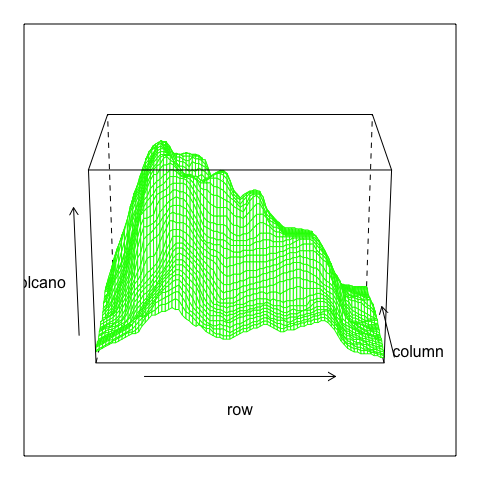

```r
lattice::wireframe(volcano, col = "green",
           screen = rglToLattice())
```

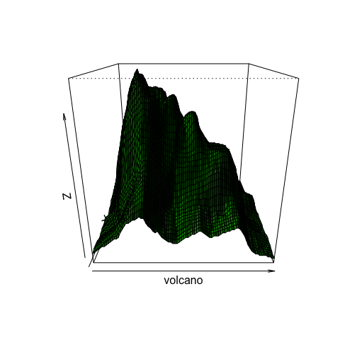

```r
angles <- rglToBase()
persp(volcano, col = "green", shade = TRUE,
      theta = angles$theta, phi = angles$phi)
```

Note that the `orientlib` package must be available for these functions to work.

### Creating `pkgdown` websites

The “Using RGL in pkgdown web sites” vignette describes how to use `rgl` in a `pkgdown` web site. The utility function [`in_pkgdown_example`](https://dmurdoch.github.io/rgl/dev/reference/in_pkgdown_example.html) can be used to detect that `pkgdown` is being used.

### Working with Javascript

The WebGL displays created using `rglwidget` rely on a large body of Javascript code included in this package. To help in development of this code, the [`makeDependency`](https://dmurdoch.github.io/rgl/dev/reference/makeDependency.html) function was written. It may be useful in other packages that include Javascript.

### Other functions

This section is for miscellaneous functions that don’t fall in any of the other categories in this document.

The [`setGraphicsDelay`](https://dmurdoch.github.io/rgl/dev/reference/setGraphicsDelay.html) function is designed to work around what appears to be a bug on macOS: if a standard plot window is opened too quickly after an `rgl` window, R can crash. This function inserts a one second delay when it appears to be needed.

## Warning: Work in Progress!

This vignette is always a work in progress. Some aspects of the `rgl` package are not described, or do not have examples. There may even be functions that are missed completely, if the following list is not empty:

```
## [1] "compare_proxy.mesh3d"
```

## Index of Functions

The following functions and constants are described in this document:

| %>% | elementId2Prefix | pipe | rgl.pop | shinyResetBrush |
| --- | --- | --- | --- | --- |
| GramSchmidt | ellipse3d | planes3d | rgl.postscript | shinySetPar3d |
| Sweave.snapshot | extrude3d | play3d | rgl.primitive | show2d |
| abclines3d | facing3d | playwidget | rgl.projection | snapshot3d |
| addNormals | figHeight | playwidgetOutput | rgl.quads | spheres3d |
| addToSubscene3d | figWidth | plot3d | rgl.quit | spin3d |
| ageControl | filledContour3d | plotmath3d | rgl.select | sprites3d |
| ageSetter | gc3d | points3d | rgl.select3d | subdivision3d |
| arc3d | getWidgetId | polygon3d | rgl.set | subsceneInfo |
| arrow3d | getr3dDefaults | pop3d | rgl.setMouseCallbacks | subsceneList |
| as.mesh3d | grid3d | projectDown | rgl.setWheelCallback | subsetControl |
| as.mesh3d.default | highlevel | propertyControl | rgl.snapshot | subsetSetter |
| as.triangles3d | hook_rgl | propertySetter | rgl.spheres | subsetSlider |
| asEuclidean | hook_webgl | propertySlider | rgl.sprites | surface3d |
| asEuclidean2 | icosahedron3d | qmesh3d | rgl.surface | terrain3d |
| asHomogeneous | identify3d | quads3d | rgl.texts | tetrahedron3d |
| asHomogeneous2 | identityMatrix | r3dDefaults | rgl.triangles | text3d |
| asRow | ids3d | readOBJ | rgl.useNULL | texts3d |
| ashape3d | in_pkgdown_example | readSTL | rgl.user2window | thigmophobe3d |
| aspect3d | layout3d | registerSceneChange | rgl.viewpoint | title3d |
| axes3d | legend3d | renderPlaywidget | rgl.window2user | tkpar3dsave |
| axis3d | light3d | renderRglwidget | rglExtrafonts | tkspin3d |
| bbox3d | lines3d | rgl.Sweave | rglFonts | tkspinControl |
| bg3d | lowlevel | rgl.Sweave.off | rglId | tmesh3d |
| bgplot3d | makeDependency | rgl.abclines | rglMouse | toggleButton |
| box3d | material3d | rgl.attrib | rglShared | toggleWidget |
| clear3d | matrixSetter | rgl.attrib.count | rglToBase | transform3d |
| clearSubsceneList | merge.mesh3d | rgl.attrib.info | rglToLattice | translate3d |
| clipMesh3d | mergeVertices | rgl.bbox | rglwidget | translationMatrix |
| clipObj3d | mesh3d | rgl.bg | rglwidgetOutput | tri |
| clipplaneControl | mfrow3d | rgl.bringtotop | rotate3d | triSht |
| clipplaneSlider | mouseMode | rgl.clear | rotationMatrix | triangles3d |
| clipplanes3d | movie3d | rgl.clipplanes | scale3d | triangulate |
| close3d | mtext3d | rgl.close | scaleMatrix | turn3d |
| contourLines3d | newSubscene3d | rgl.cur | scene3d | useSubscene3d |
| cube3d | next3d | rgl.dev.list | sceneChange | vertexControl |
| cuboctahedron3d | normalize.mesh3d | rgl.getMouseCallbacks | segments3d | vertexSetter |
| cur3d | observer3d | rgl.getWheelCallback | select3d | view3d |
| currentSubscene3d | octahedron3d | rgl.ids | selectionFunction3d | wire3d |
| cylinder3d | oh3d | rgl.init | selectpoints3d | writeASY |
| decorate3d | open3d | rgl.light | set3d | writeOBJ |
| deform.mesh3d | par3d | rgl.lines | setGraphicsDelay | writePLY |
| delFromSubscene3d | par3dinterp | rgl.linestrips | setUserShaders | writeSTL |
| deldir | par3dinterpControl | rgl.material | setupKnitr | writeWebGL |
| divide.mesh3d | par3dinterpSetter | rgl.open | shade3d |  |
| dodecahedron3d | particles3d | rgl.pixels | shadow3d |  |
| dot3d | pch3d | rgl.planes | shapelist3d |  |
| drape3d | persp3d | rgl.points | shinyGetPar3d |  |